# Stroke Prediction with ML

Spring 2025 Data Science Project  
Ankit Nakhawa and Ayush Mishra  
**Ankit Nakhawa** Contributions:

- Helped come up with the project idea and found the Kaggle Dataset
- Preprocessed data
- Summary Statistics
- Worked on 3 Conclusions for Checkpoint #2
- Chose which ML models to use
- ML Model Training for initial dataset
- Visualizations
- Conclusion
- Final Report

**Ayush Mishra** Contributions:

- Helped come up with the project idea
- Preprocessed data
- Data Exploration
- Worked on 3 Conclusions for Checpoint #2
- Feature Engineering/Selection for ML Model
- ML Model Training for dataset with specified features
- Visualizations
- Result Analysis
- Final Report

# Introduction

Our topic is predicting strokes in patients using machine learning models based on collected information on patient demographics and medical history. Our goal is to analyze different features and predict if an individual is at-risk of having a stroke. \

Strokes are one of the leading causes of death and long-term disability worldwide, accounting for approximately 11% of total deaths globally [1]. Early identification of individuals at high risk for stroke can drastically improve clinical outcomes by enabling preventative care, timely diagnosis, and resource prioritization [2].

Some of the questions we are trying to answer are:

- Can we build an accurate ML model to predict the risk of stroke in patients using available health data?
- Which features are most relevant to risk of stroke?
- Which machine learning model (Logistic Regression, SVM, Random Forest, etc.) performs best in terms of recall, particularly to reduce false negatives?

These questions are important because a ML tool to predict risk of stroke could be vital in enabling early detection and treatment. If our model predicts one at-risk of stroke, they can seek medical help early on and seek medical treatment to better understand and prevent future strokes. Reducing false negatives is crucial in medical applications as missing a patient who is actually at risk can lead serious bodily injury, even death. In addition, understanding which factors most influence stroke risk can help guide public health strategies, allowing society to fight strokes before they even happen.

Sources: [1] World Health Organization (2023). *Stroke: Key facts*. Retrieved from: https://www.who.int/news-room/fact-sheets/detail/the-top-10-causes-of-death  
[2] Feigin, V. L., et al. (2021). *Global burden of stroke: Developing priority strategies*. The Lancet Neurology, 20(10), 775–790. doi:10.1016/S1474-4422(21)00239-4

There is already data publicly available related to stroke risk in patients. The following data used in this EDA is taken from [Fedesoriano's Stroke Prediction Dataset - 11 clinical features for predicting stroke events](https://https://www.kaggle.com/datasets/fedesoriano/stroke-prediction-dataset/code). We chose this dataset as it has a representation of patients who either had a stroke or didn't have one, and provides additional information related to their other health conditions, age, gender, bmi, and other potential stroke indicators.

# Dataset Curation and Preprocessing

```python
import kagglehub
import pandas as pd
import numpy as np
import matplotlib.pyplot as plt
import seaborn as sns
from scipy.stats import chi2_contingency, ttest_ind

path = kagglehub.dataset_download("fedesoriano/stroke-prediction-dataset")
path += '/healthcare-dataset-stroke-data.csv'

print("Path to dataset files:", path)

stroke_df = pd.read_csv(path)
stroke_df
```

```
Downloading from https://www.kaggle.com/api/v1/datasets/download/fedesoriano/stroke-prediction-dataset?dataset_version_number=1...
```

```
Extracting files...
```

```
Path to dataset files: /root/.cache/kagglehub/datasets/fedesoriano/stroke-prediction-dataset/versions/1/healthcare-dataset-stroke-data.csv
```

|  | id | gender | age | hypertension | heart_disease | ever_married | work_type | Residence_type | avg_glucose_level | bmi | smoking_status | stroke |
| --- | --- | --- | --- | --- | --- | --- | --- | --- | --- | --- | --- | --- |
| 0 | 9046 | Male | 67.0 | 0 | 1 | Yes | Private | Urban | 228.69 | 36.6 | formerly smoked | 1 |
| 1 | 51676 | Female | 61.0 | 0 | 0 | Yes | Self-employed | Rural | 202.21 | NaN | never smoked | 1 |
| 2 | 31112 | Male | 80.0 | 0 | 1 | Yes | Private | Rural | 105.92 | 32.5 | never smoked | 1 |
| 3 | 60182 | Female | 49.0 | 0 | 0 | Yes | Private | Urban | 171.23 | 34.4 | smokes | 1 |
| 4 | 1665 | Female | 79.0 | 1 | 0 | Yes | Self-employed | Rural | 174.12 | 24.0 | never smoked | 1 |
| ... | ... | ... | ... | ... | ... | ... | ... | ... | ... | ... | ... | ... |
| 5105 | 18234 | Female | 80.0 | 1 | 0 | Yes | Private | Urban | 83.75 | NaN | never smoked | 0 |
| 5106 | 44873 | Female | 81.0 | 0 | 0 | Yes | Self-employed | Urban | 125.20 | 40.0 | never smoked | 0 |
| 5107 | 19723 | Female | 35.0 | 0 | 0 | Yes | Self-employed | Rural | 82.99 | 30.6 | never smoked | 0 |
| 5108 | 37544 | Male | 51.0 | 0 | 0 | Yes | Private | Rural | 166.29 | 25.6 | formerly smoked | 0 |
| 5109 | 44679 | Female | 44.0 | 0 | 0 | Yes | Govt_job | Urban | 85.28 | 26.2 | Unknown | 0 |

5110 rows × 12 columns

The dataset includes several categorical variables that contain qualitiative data. Let's code this data into numbers to make it easier to work with when training our ML model.  
In addition, let's handle all the rows that contain null/missing values. We can drop them since our dataset is big and we will still have lots of data left over

```python
print("\nFirst five rows of the dataset:")
print(stroke_df.head())

#Inspect info about columns
print("\nDataFrame Info:")
stroke_df.info()

#Parse Gender into quantitative data, male to 0 and female to 1 and Other to 2
gender_map = {'Male': 0, 'Female': 1, 'Other': 2}
stroke_df['gender'] = stroke_df['gender'].apply(lambda x : gender_map[x])

#Parse ever_married into quantitative data, No to 0 and Yes to 1
stroke_df['ever_married'] = stroke_df['ever_married'].map({'No': 0, 'Yes': 1})

#Parse work_type into quantitative data, Private to 0, Self-employed to 1, Govt_job to 2, children to 3, Never_worked to 4
stroke_df['work_type'] = stroke_df['work_type'].map({'Private': 0, 'Self-employed': 1, 'Govt_job': 2, 'children': 3, 'Never_worked': 4})

#Parse Residence_type into quantitative data, Urban to 0 and Rural to 1
stroke_df['Residence_type'] = stroke_df['Residence_type'].map({'Urban': 0, 'Rural': 1})

#Parse smoking_status into quantitative data, never smoked to 0, formerly smoked to 1, smokes to 2, Unknown to 3
stroke_df['smoking_status'] = stroke_df['smoking_status'].map({'never smoked': 0, 'formerly smoked': 1, 'smokes': 2, 'Unknown': 3})

#Drop missing values
stroke_df.dropna(inplace=True)
print(stroke_df.head())

#Check for missing values
missing_values = stroke_df.isnull().sum()
print("\nMissing values in each column:\n", missing_values)
```

```
First five rows of the dataset:
      id  gender   age  hypertension  heart_disease ever_married  \
0   9046    Male  67.0             0              1          Yes
1  51676  Female  61.0             0              0          Yes
2  31112    Male  80.0             0              1          Yes
3  60182  Female  49.0             0              0          Yes
4   1665  Female  79.0             1              0          Yes

       work_type Residence_type  avg_glucose_level   bmi   smoking_status  \
0        Private          Urban             228.69  36.6  formerly smoked
1  Self-employed          Rural             202.21   NaN     never smoked
2        Private          Rural             105.92  32.5     never smoked
3        Private          Urban             171.23  34.4           smokes
4  Self-employed          Rural             174.12  24.0     never smoked

   stroke
0       1
1       1
2       1
3       1
4       1

DataFrame Info:
<class 'pandas.core.frame.DataFrame'>
RangeIndex: 5110 entries, 0 to 5109
Data columns (total 12 columns):
 #   Column             Non-Null Count  Dtype
---  ------             --------------  -----
 0   id                 5110 non-null   int64
 1   gender             5110 non-null   object
 2   age                5110 non-null   float64
 3   hypertension       5110 non-null   int64
 4   heart_disease      5110 non-null   int64
 5   ever_married       5110 non-null   object
 6   work_type          5110 non-null   object
 7   Residence_type     5110 non-null   object
 8   avg_glucose_level  5110 non-null   float64
 9   bmi                4909 non-null   float64
 10  smoking_status     5110 non-null   object
 11  stroke             5110 non-null   int64
```

[output cut: 15 more lines]

```

Missing values in each column:
 id                   0
gender               0
age                  0
hypertension         0
heart_disease        0
ever_married         0
work_type            0
Residence_type       0
avg_glucose_level    0
bmi                  0
smoking_status       0
stroke               0
dtype: int64
```

**Exploring Basic Statistical Relationships**

```python
print(stroke_df.describe())
```

```
                 id       gender          age  hypertension  heart_disease  \
count   4909.000000  4909.000000  4909.000000   4909.000000    4909.000000
mean   37064.313506     0.590548    42.865374      0.091872       0.049501
std    20995.098457     0.492197    22.555115      0.288875       0.216934
min       77.000000     0.000000     0.080000      0.000000       0.000000
25%    18605.000000     0.000000    25.000000      0.000000       0.000000
50%    37608.000000     1.000000    44.000000      0.000000       0.000000
75%    55220.000000     1.000000    60.000000      0.000000       0.000000
max    72940.000000     2.000000    82.000000      1.000000       1.000000

       ever_married    work_type  Residence_type  avg_glucose_level  \
count   4909.000000  4909.000000     4909.000000        4909.000000
mean       0.652679     0.842534        0.492768         105.305150
std        0.476167     1.124057        0.499999          44.424341
min        0.000000     0.000000        0.000000          55.120000
25%        0.000000     0.000000        0.000000          77.070000
50%        1.000000     0.000000        0.000000          91.680000
75%        1.000000     2.000000        1.000000         113.570000
max        1.000000     4.000000        1.000000         271.740000

               bmi  smoking_status       stroke
count  4909.000000     4909.000000  4909.000000
mean     28.893237        1.377063     0.042575
std       7.854067        1.262513     0.201917
min      10.300000        0.000000     0.000000
25%      23.500000        0.000000     0.000000
50%      28.100000        1.000000     0.000000
75%      33.100000        3.000000     0.000000
max      97.600000        3.000000     1.000000
```

# Data Exploration and Summary Statistics

**Exploring Age Distribution**

We are creating a histogram of the ages in this dataset to visualize the range and frequency of our data. We can see that this dataset captures individuals of all ages, with the highest frequencies at individuals in their 50's.

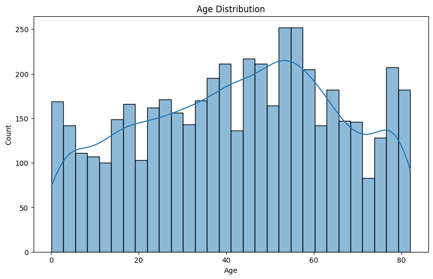

```python
plt.figure(figsize=(10, 6))
sns.histplot(stroke_df['age'], bins=30, kde=True)
plt.title('Age Distribution')
plt.xlabel('Age')
plt.ylabel('Count')
plt.show()
```

**Exploring Smoking Status Distribution**

Let's make a bar graph displaying the frequency of datapoints who never smoked (0), formerly smoked (1), currently smokes (2), or whose smoking habits is unknown (3). We can see that the majority of individuals in the dataset either never smoked or has their smoking habits unknown. We can see that the amount that smokes either now or in the past are close to each other around 750

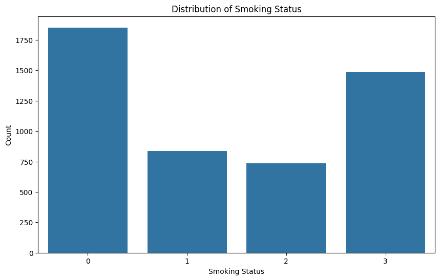

```python
#{'never smoked': 0, 'formerly smoked': 1, 'smokes': 2, 'Unknown': 3}
plt.figure(figsize=(10, 6))
sns.countplot(x='smoking_status', data=stroke_df)
plt.title('Distribution of Smoking Status')
plt.xlabel('Smoking Status')
plt.ylabel('Count')
plt.show()
```

**Exploring Glucose Level Distribution**

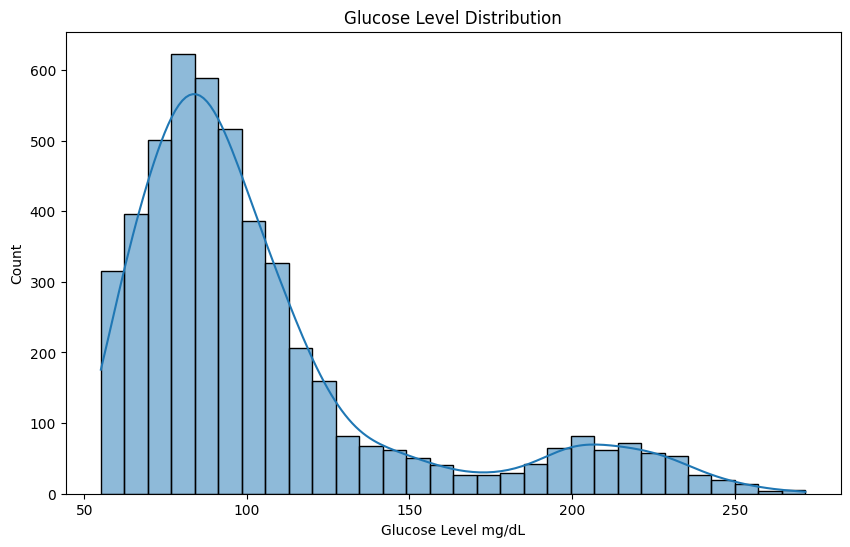

```python
#Exploring Glucose Level Distribution
plt.figure(figsize=(10, 6))
sns.histplot(stroke_df['avg_glucose_level'], bins=30, kde=True)
plt.title('Glucose Level Distribution')
plt.xlabel('Glucose Level mg/dL')
plt.ylabel('Count')
```

**Exploring Stroke Distribution**

Let's generate a pie chart showing the distribution of our target variable, displaying those who had a stroke vs those who did not have a stroke, values of 1 and 0 respectively. We can see that our dataset is extremely imabalanced as the categories we are targeting (binary in this case) are not represented equally. Almost all of the individuals in the dataset did not have a stroke, with a small minority having reported a stroke.

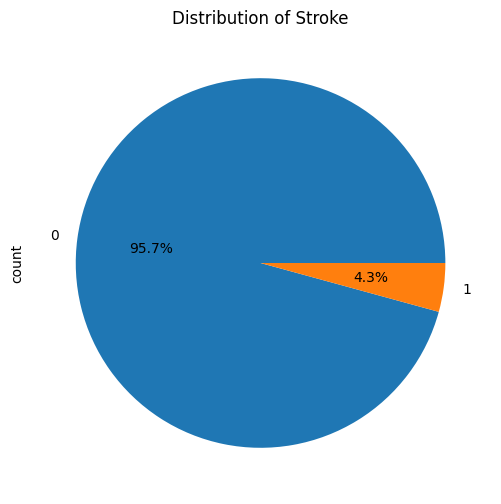

```python
#Pie chart of having stroke vs not having strokes
plt.figure(figsize=(10, 6))
stroke_df['stroke'].value_counts().plot(kind='pie', autopct='%1.1f%%')
plt.title('Distribution of Stroke')
plt.show()
```

# **Starting Conclusion #1**

Let's investigate the relationship between age and stroke

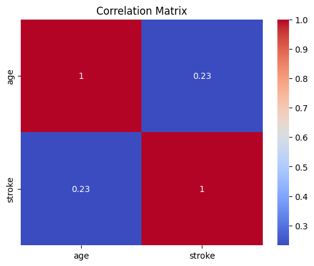

```python
#Correlation Matrix between age and stroke
corr_matrix = stroke_df[['age', 'stroke']].corr()
sns.heatmap(corr_matrix, annot=True, cmap='coolwarm')
plt.title('Correlation Matrix')
plt.show()
```

From the correlation matrix above, we can see that age and stroke-risk have a weak, positive relationship. Age may be a factor in stroke-risk, but it certainly isn't the only factor.

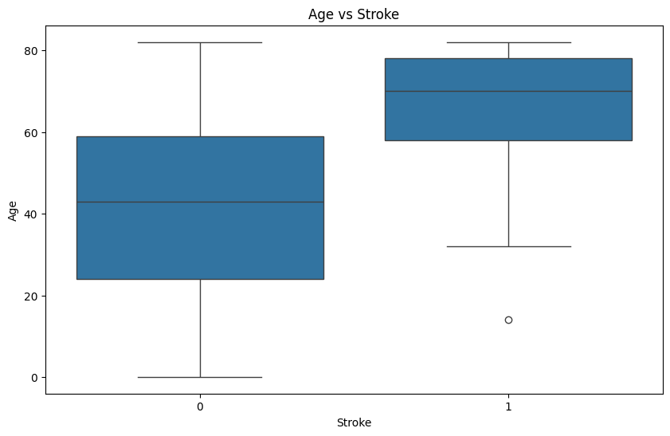

```python
#Comparing Age and Stroke with a plot to help visualize more
plt.figure(figsize=(10, 6))
sns.boxplot(x='stroke', y='age', data=stroke_df)
plt.title('Age vs Stroke')
plt.xlabel('Stroke')
plt.ylabel('Age')
plt.show()
```

Above is a box and whisker plot displaying the ages of those who had a stroke and did not have a stroke. The lone dots are outliers.

# **Conclusion 1:**

I used a correlation matrix to find the correlation coefficient between the age of the patient and their history of having strokes or not. As this is a categorical variable and a quantative variable, I also used a boxplot to help better visualize the distribution of data.  
We can see here that the relationship between age and having a stroke is weak and positive, as seen with a correlation coefficient of r=0.23. From this, although the correlation is weak, we can assume a positive correlation and deduct that as age increases, the risk of stroke increases as well.  
To better investigate this, we can look at the boxplot, separating the data by those who have had a stroke and those who did not. Here we can see that there exists patients of all ages who have not had a stroke. There is an even distribution among all ages. However, by focusing on the right column, we can see that those who had a stroke fall in a more narrow range of ages, all of them being on the older side. 75% of patients who had a stroke are above the age of ~60 and 50% of patients who had a stroke are above the age of ~70. There is one lone outlier, but since this is just one, we can ignore it.  
Our conclusion is that strokes primarily happen to people of older ages, but being older does not necessesarily mean that you will get a stroke.

# **Starting Conclusion #2**

Let's perform a Chi-Square Test of Independence to see if the relationship between Smoking Status and Stroke-risk is statistically significant.

```python
# Method 2: Chi-Square Test for Smoking Status vs. Stroke status
#First, create subset without Unknown smoking status
stroke_df_known_smoking = stroke_df[stroke_df['smoking_status'] != 3]

#Create a Contingency Table
contingency_table = pd.crosstab(stroke_df_known_smoking['smoking_status'], stroke_df_known_smoking['stroke'])
chi2, p, dof, ex = chi2_contingency(contingency_table)
print(f"\nChi-square Test between Smoking Status and Stroke Status:")
print(f"Chi2 = {chi2:.4f}, p-value = {p}, dof = {dof}")
```

```
Chi-square Test between Smoking Status and Stroke Status:
Chi2 = 5.9932, p-value = 0.049956999455472766, dof = 2
```

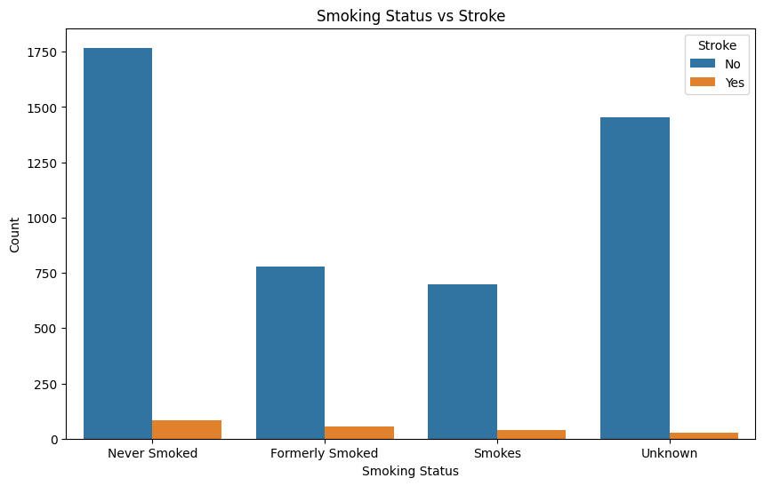

```python
#Comparing Smoking Status and Stroke
plt.figure(figsize=(10, 6))
sns.countplot(x='smoking_status', hue='stroke', data=stroke_df)
plt.title('Smoking Status vs Stroke')
plt.xlabel('Smoking Status')
plt.ylabel('Count')
#Change labels of variables to yes or no
plt.xticks([0, 1, 2, 3], ['Never Smoked', 'Formerly Smoked', 'Smokes', 'Unknown'])
plt.legend(title='Stroke', labels=['No', 'Yes'])
plt.show()
```

# **Conclusion #2:**

We ran a Chi-Squared Test to test the categorical variables of Smoking Status and having a prior Stroke. The Chi-Squared Test returned a p-value of 0.04996, just under the alpha-level of 0.05, meaning we can reject the null hypothesis that there is no association. This means that we can say that there is an association between smoking and having a stroke. While the Chi-Square Test cannto reveal the direction of the association, we can say that there is an association.

# **Starting Conclusion #3**

Let's run a T-Test to determine if the relationship between gluclose level and stroke-risk are statistically significant. The research hypothesis is that these two features are related and the null hypothesis is that these two featuers have no association. If the p-value of this T-Test is <0.05, we can reject the null hypothesis and "accept" the research hypothesis.

```python
#T-Test for Glucose Level and Stroke
#Here we are comparing the counts of the two columns, filtered by having a stroke or not
glucose_stroke = stroke_df[stroke_df['stroke'] == 1]['avg_glucose_level']
glucose_no_stroke = stroke_df[stroke_df['stroke'] == 0]['avg_glucose_level']
t_stat, p_value = ttest_ind(glucose_stroke, glucose_no_stroke)
print(f"T-Statistic: {t_stat}, p-value: {p_value}")
```

```
T-Statistic: 9.827770450292483, p-value: 1.3799691107259876e-22
```

Below is a box and whisker plot displaying the glucose levels of those who had a stroke and did not have a stroke. The graph shows the medians and upper and lower quartiles, where lone dots are outliers.

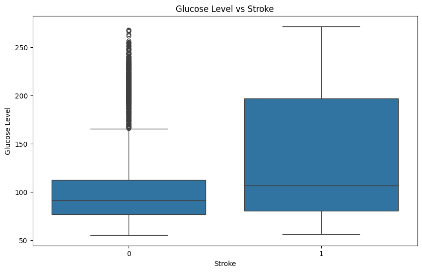

```python
#Comparing Glucose Level and Stroke
plt.figure(figsize=(10, 6))
sns.boxplot(x='stroke', y='avg_glucose_level', data=stroke_df)
plt.title('Glucose Level vs Stroke')
plt.xlabel('Stroke')
plt.ylabel('Glucose Level')
```

# **Conclusion #3:**

We ran a T-Test to compare the numerical variable of Glucose Levels and having a stroke. The T-Test returned a p-value under the alpha level 0.05, meaning we can reject the null hypothesis. This means that there is a statistically significant difference between the means of the two distributions of Glucose Levels based on if the patient had a stroke or not. This means that the Glucose Levels are different in those who had a stroke compared to those who did not have a stroke. We can conclude, based on this, that there is a correlation between Glucose Levels and having a stroke, but we cannot infer causation or direction. We also noted that there were a lot of outliers in the no-stroke distribution, which may inflate variance, inflating the p-value we got. However, since the p-value was very small, we can assume that the results are accurate and are statistically signifcant regardless.

## Feature Engineering

We will find the best features to include in our model

```
stroke               1.000000
age                  0.232331
hypertension         0.142515
avg_glucose_level    0.138936
heart_disease        0.137938
ever_married         0.105089
work_type            0.057534
smoking_status       0.052596
bmi                  0.042374
gender               0.007021
Residence_type       0.006031
id                   0.004839
Name: stroke, dtype: float64
```

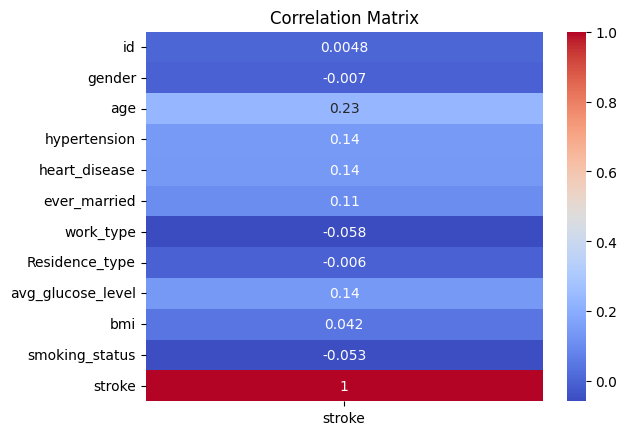

```python
#create a correlation matrix
corr_matrix = stroke_df.corr()
corr_matrix_values = corr_matrix['stroke'].abs().sort_values(ascending=False)
print(corr_matrix_values)
corr_matrix = corr_matrix[['stroke']]
sns.heatmap(corr_matrix, annot=True, cmap='coolwarm')
plt.title('Correlation Matrix')
plt.show()
```

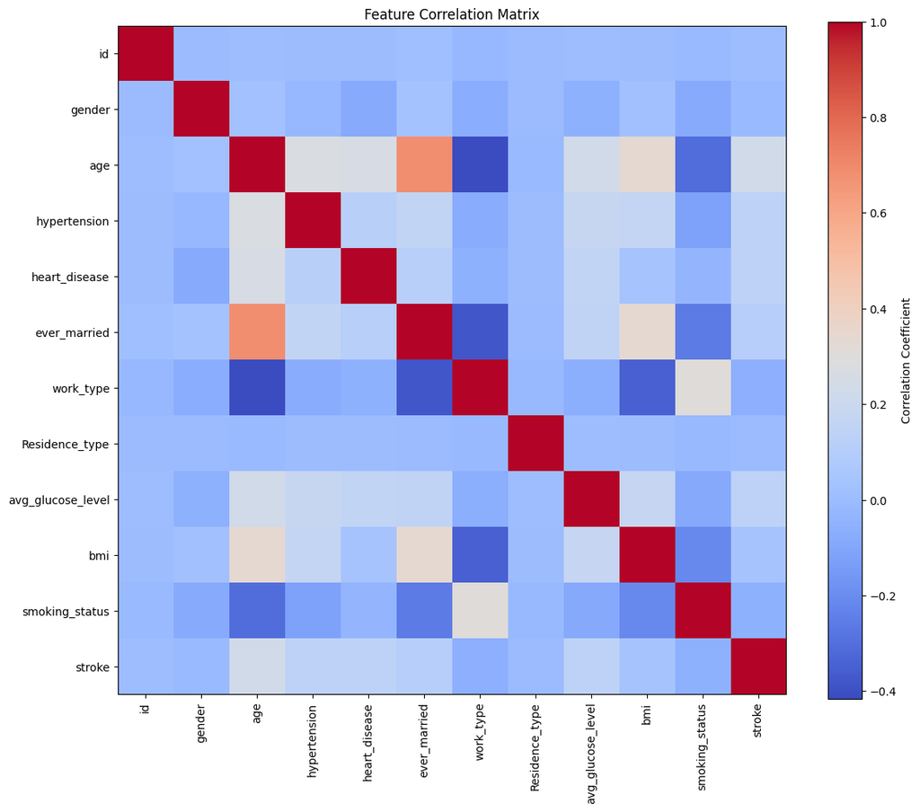

```python
import kagglehub
import pandas as pd
import matplotlib.pyplot as plt


# 3. Compute correlations
corr = stroke_df.corr()
features = corr.columns.tolist()

# 4. Plot heatmap using matplotlib only
plt.figure(figsize=(12, 10))
plt.imshow(corr, interpolation='none', cmap='coolwarm')
plt.colorbar(label='Correlation Coefficient')
plt.xticks(range(len(features)), features, rotation=90)
plt.yticks(range(len(features)), features)
plt.title('Feature Correlation Matrix')
plt.tight_layout()
plt.show()
```

# Analysis

As we can see, work_type, smoking_status, bmi, gender, and Residence_type all have correlations under 0.1. However, there is a steep dropoff between bmi's correlation and the correlation values from gender and residence_type, the latter two being under 0.01. We can also see work_type, smoking_status, and bmi are low correlation scores.  
This presents an issue where we don't want to drop potentially useful data, but also don't want to have meaningless data that could cause our model to overfit.  
To solve this, we can have two sets of data: one with only the high impacting features and one where we are conservative and include borderline impacting features (like work_type, smoking_status, and bmi). We can train two models and compare their recall scores to see which one has a higher recall score - since we want to ensure that we don't miss out on any false negatives.

Weak or non-linear relations: Work_type, smoking_status, residence_type show almost no linear correlation with stroke—if they matter, it’ll likely be in a nonlinear way or only for certain subgroups.

# ML Strategy and Selection

As mentioned before, we are going to check the high imipact features vs conservative ones and see how much model performance improves by adding the other features. Below is a test where we add the heavy impact feature sets then the less important ones.

```python
# 1. Define feature sets
high_feats = ['age', 'hypertension', 'heart_disease', 'avg_glucose_level', 'ever_married']
cons_feats = high_feats + ['work_type', 'smoking_status', 'bmi']

# 2. Split data (uses existing, preprocessed stroke_df)
X = stroke_df.drop(['id', 'stroke'], axis=1)
y = stroke_df['stroke']
X_train, X_test, y_train, y_test = train_test_split(
    X, y, test_size=0.3, stratify=y, random_state=42
)

# 3. Train & evaluate
clf = LogisticRegression(class_weight='balanced', max_iter=1000, random_state=42)

# High-impact features
clf.fit(X_train[high_feats], y_train)
rec_high = recall_score(y_test, clf.predict(X_test[high_feats]))

# Conservative features
clf.fit(X_train[cons_feats], y_train)
rec_cons = recall_score(y_test, clf.predict(X_test[cons_feats]))

# 4. Report
print(f"Recall (High-Impact):   {rec_high:.2f}")
print(f"Recall (Conservative):  {rec_cons:.2f}")
```

```
Recall (High-Impact):   0.68
Recall (Conservative):  0.70
```

From this, we can tell that we only get +0.02 more in accuracy of true positive cases. Though this may not seem important at first, having more true positives that are detected means fewer missed stroke patients, which is often more important than avoiding false alarms.

This tells us that Work type, smoking status, and BMI each carry a bit of additional signal that wasn’t captured by age, hypertension, heart disease, glucose, and marital status alone. Thus, going forward in our data analysis, for any ML models we should include these features.

## Why we use Logistic Regression

Logistic regression is ideal here because it directly models the binary outcome (stroke vs. no stroke) as a linear function based on the medical information as the features. This will give good probability scores for the binary variable and will help us determine precision scores. This will provide uys a clear benchmark before we go to more complex modeling.

```python
# Combined High-Impact + Borderline Features Logistic Regression

# 1. Compute feature–target correlations
corr_with_stroke = stroke_df.corr()['stroke'].drop('stroke')

# 2. Define high-impact (|r| > 0.10) and borderline features
high_feats       = corr_with_stroke[abs(corr_with_stroke) > 0.10].index.tolist()
borderline_feats = ['work_type', 'smoking_status', 'bmi']

# Combine them
selected_features = high_feats + borderline_feats
print("Selected features:", selected_features)

# 3. Prepare data using the combined feature set
X_sel = stroke_df[selected_features]
y     = stroke_df['stroke']

# 4. Train/test split
from sklearn.model_selection import train_test_split
X_train_s, X_test_s, y_train, y_test = train_test_split(
    X_sel, y, test_size=0.3, random_state=42, stratify=y
)

# 5. Re-train logistic regression on this feature set
from sklearn.linear_model import LogisticRegression
clf_sel = LogisticRegression(class_weight='balanced', max_iter=1000, random_state=42)
clf_sel.fit(X_train_s, y_train)

# 6. Evaluate
from sklearn.metrics import classification_report, roc_auc_score
y_pred_s = clf_sel.predict(X_test_s)
y_prob_s = clf_sel.predict_proba(X_test_s)[:, 1]

print("Classification Report (High-Impact + Borderline):")
print(classification_report(y_test, y_pred_s))
print("ROC AUC (High-Impact + Borderline):", roc_auc_score(y_test, y_prob_s))
```

```
Selected features: ['age', 'hypertension', 'heart_disease', 'ever_married', 'avg_glucose_level', 'work_type', 'smoking_status', 'bmi']
Classification Report (High-Impact + Borderline):
              precision    recall  f1-score   support

           0       0.98      0.76      0.86      1410
           1       0.12      0.70      0.20        63

    accuracy                           0.76      1473
   macro avg       0.55      0.73      0.53      1473
weighted avg       0.95      0.76      0.83      1473

ROC AUC (High-Impact + Borderline): 0.8224361139254757
```

An AUC of 0.822 means that if you randomly pick one patient who had a stroke and one who didn’t, there’s about an 82.2% chance your model will assign a higher predicted probability to the true stroke case than to the non-stroke case. This tells us that our model which includes the high impact and conservative features is able to differentiate and map the patients relation to eachother based on the stroke risk.

## Using Decision Trees

Decision trees automatically learn a series of “if–then” rules that split your feature space into regions of similar stroke‐risk, making them highly interpretable (“Patients older than 60 AND glucose > 120 → high risk”). There is no need to scale the data as it makes individual decisions based on trying to improve an impurity score between the decisions. This is also good because we have numerical and categorical data, so we can make these logical decisions based on thresholds.

```python
# Decision Tree Baseline

from sklearn.model_selection import train_test_split
from sklearn.tree import DecisionTreeClassifier
from sklearn.metrics import classification_report, roc_auc_score

# 1. Prepare data
X = stroke_df.drop(['id','stroke'], axis=1)
y = stroke_df['stroke']
X_train, X_test, y_train, y_test = train_test_split(
    X, y, test_size=0.3, stratify=y, random_state=42
)

# 2. Train a balanced decision tree
clf_dt = DecisionTreeClassifier(
    max_depth=5,
    class_weight='balanced',
    random_state=42
)
clf_dt.fit(X_train, y_train)

# 3. Evaluate
y_pred_dt  = clf_dt.predict(X_test)
y_prob_dt  = clf_dt.predict_proba(X_test)[:,1]
print(classification_report(y_test, y_pred_dt))
print("ROC AUC:", roc_auc_score(y_test, y_prob_dt))
```

```
              precision    recall  f1-score   support

           0       0.97      0.66      0.79      1410
           1       0.08      0.62      0.13        63

    accuracy                           0.66      1473
   macro avg       0.52      0.64      0.46      1473
weighted avg       0.94      0.66      0.76      1473

ROC AUC: 0.6643082292018462
```

## Improvement with Gradient Boosting

Gradient boosting builds an ensemble of many small trees sequentially, where each new tree corrects the errors of the previous ones. This focus on hard‐to‐predict cases generally gives higher accuracy and AUC than a single tree while still preserving some interpretability through feature‐importance scores. It’s especially effective on tabular data with mixed feature types and can automatically model complex relationships.

```python
# Gradient Boosting Classifier

from sklearn.ensemble import GradientBoostingClassifier
from sklearn.metrics import classification_report, roc_auc_score

# 1. (Re)use the same split defined above

# 2. Train a gradient boosting model
clf_gb = GradientBoostingClassifier(
    n_estimators=100,
    learning_rate=0.1,
    random_state=42
)
clf_gb.fit(X_train, y_train)

# 3. Evaluate
y_pred_gb = clf_gb.predict(X_test)
y_prob_gb = clf_gb.predict_proba(X_test)[:,1]
print(classification_report(y_test, y_pred_gb))
print("ROC AUC:", roc_auc_score(y_test, y_prob_gb))
```

```
              precision    recall  f1-score   support

           0       0.96      1.00      0.98      1410
           1       0.00      0.00      0.00        63

    accuracy                           0.96      1473
   macro avg       0.48      0.50      0.49      1473
weighted avg       0.92      0.96      0.94      1473

ROC AUC: 0.8143588877631431
```

Moving from an AUC of 0.66 (our single decision‐tree model) up to 0.81 with gradient boosting means the boosted ensemble is substantially better at ranking true stroke cases above non‐stroke cases, no matter where you set your probability cutoff. Concretely, an AUC of 0.81 tells you that if you randomly pick one patient who did have a stroke and one who didn’t, the gradient-boosting model will assign a higher risk score to the true stroke patient about 81% of the time—versus only 66% for the lone decision tree. Because AUC aggregates performance over all possible thresholds, this jump shows that boosting yields a more reliable trade-off between sensitivity (catching strokes) and specificity (avoiding false alarms) across the board.

## Visualizing the Decision Tree

Here is the visualized tree. From this we can see that decisions are being made based on the different factors. For instance, on the far left child of the root, the age is being split based on under 37.5. The gini scores represent the impurity based on the decisions, where we aim to reduce it to 0 indicating that we have made a clear decision. As you can see, some of the impourity scores are still high at the end of the tree. These potentially contribute to the innacuracies, and the gini impurity scores that are a lot higher occur when the decision tree makes decisions off of the lower importance features.

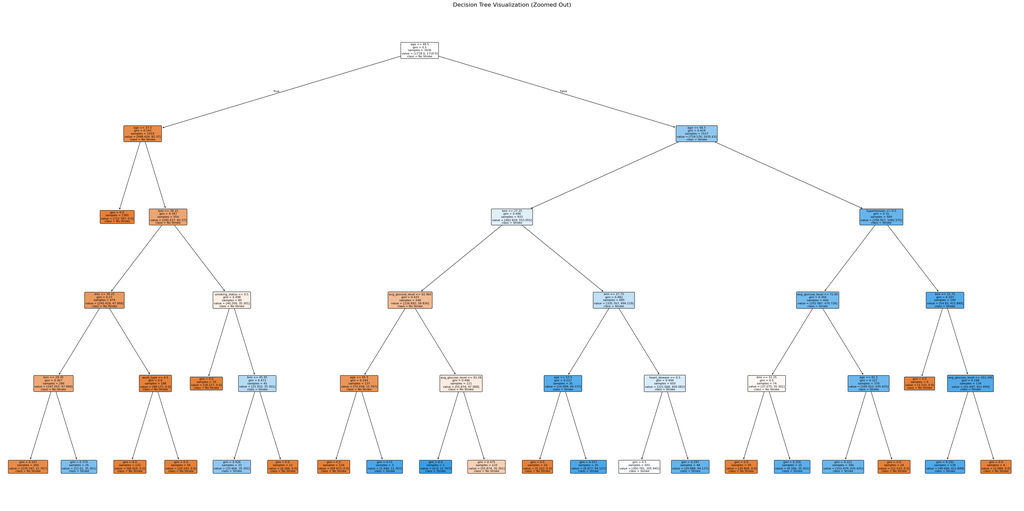

```python
# Zoomed‐out Decision Tree Visualization

import matplotlib.pyplot as plt
from sklearn.tree import plot_tree

# Create a larger, higher‐resolution figure
fig, ax = plt.subplots(figsize=(40, 20), dpi=100)

# Plot the tree on this axes, with a smaller font
plot_tree(
    clf_dt,
    feature_names=X_train.columns,
    class_names=['No Stroke', 'Stroke'],
    filled=True,
    rounded=True,
    fontsize=8,
    ax=ax
)

plt.title("Decision Tree Visualization (Zoomed Out)", fontsize=16)
plt.tight_layout()
plt.show()
```

## Showing Performance for Trees + Regression vs. Other Models

Our problem—predicting whether a patient will have a stroke—is a **binary classification** task. We’ll compare trees with other models, keeping in mind these various advantages and disadvantages:

1. **Logistic Regression**
   - A linear baseline.
   - Pros: interpretable coefficients, fast to train.
   - Cons: can’t capture complex nonlinear relationships easily
2. **Decision Tree**
   - splits on feature thresholds.
   - Pros: handles nonlinearity and interactions automatically, easy to visualize.
   - Cons: prone to overfitting if not pruned.

```python
from sklearn.model_selection import train_test_split
from sklearn.linear_model import LogisticRegression
from sklearn.tree import DecisionTreeClassifier
from sklearn.ensemble import RandomForestClassifier, GradientBoostingClassifier
from sklearn.svm import SVC

X_conservative = stroke_df.drop(['id', 'stroke', 'gender', 'Residence_type'], axis=1)
X_normal = stroke_df.drop(['id', 'stroke', 'gender', 'Residence_type', 'work_type', 'smoking_status', 'bmi'], axis=1)
y = stroke_df['stroke']

# stratified split to preserve class balance
X_train_conservative, X_test_conservative, y_train_conservative, y_test_conservative = train_test_split(
    X_conservative, y, test_size=0.3, random_state=42, stratify=y
)
X_train, X_test, y_train, y_test = train_test_split(
    X_normal, y, test_size=0.3, random_state=42, stratify=y
)

# instantiate all models
models_conservative = {
    "Logistic Regression": LogisticRegression(max_iter=1000),
    "Decision Tree": DecisionTreeClassifier(max_depth=5, random_state=42),
    "Random Forest": RandomForestClassifier(n_estimators=100, random_state=42),
    "SVM (RBF)": SVC(kernel='rbf', probability=True, random_state=42),
    "Gradient Boosting": GradientBoostingClassifier(
        n_estimators=100,
        learning_rate=0.1,
        random_state=42
    )
}
models = {
    "Logistic Regression": LogisticRegression(max_iter=1000),
    "Decision Tree": DecisionTreeClassifier(max_depth=5, random_state=42),
    "Random Forest": RandomForestClassifier(n_estimators=100, random_state=42),
    "SVM (RBF)": SVC(kernel='rbf', probability=True, random_state=42),
    "Gradient Boosting": GradientBoostingClassifier(
        n_estimators=100,
        learning_rate=0.1,
        random_state=42
    )
}
```

Let's train each model, having a model for each dataset. This way we can compare between models and between datasets.

```python
#model training, resampling to account for dataset imbalance

from imblearn.over_sampling import SMOTE

smote = SMOTE(random_state=42)
X_train, y_train = smote.fit_resample(X_train, y_train)
X_train_conservative, y_train_conservative = smote.fit_resample(X_train_conservative, y_train_conservative)
for name, clf in models.items():
  clf.fit(X_train, y_train)
for name, clf in models_conservative.items():
  clf.fit(X_train_conservative, y_train_conservative)
```

Let's get the cross validation score for each model, so we can compare which dataset the model works best at (dataset with reduced features or dataset with more features).

```python
#test to see which one we want to use
from sklearn.model_selection import cross_val_score

for name, clf in models.items():
  score = cross_val_score(clf, X_train, y_train, cv=5).mean()
  print(f"{name} Normal Score: {score:.4f}")
for name, clf in models_conservative.items():
  score = cross_val_score(clf, X_train_conservative, y_train_conservative, cv=5).mean()
  print(f"{name} Conservative Score: {score:.4f}")
```

```
Logistic Regression Normal Score: 0.9575
Decision Tree Normal Score: 0.9529
Random Forest Normal Score: 0.9491
SVM (RBF) Normal Score: 0.9575
Gradient Boosting Normal Score: 0.9537
Logistic Regression Conservative Score: 0.9572
Decision Tree Conservative Score: 0.9502
Random Forest Conservative Score: 0.9555
SVM (RBF) Conservative Score: 0.9575
Gradient Boosting Conservative Score: 0.9540
```

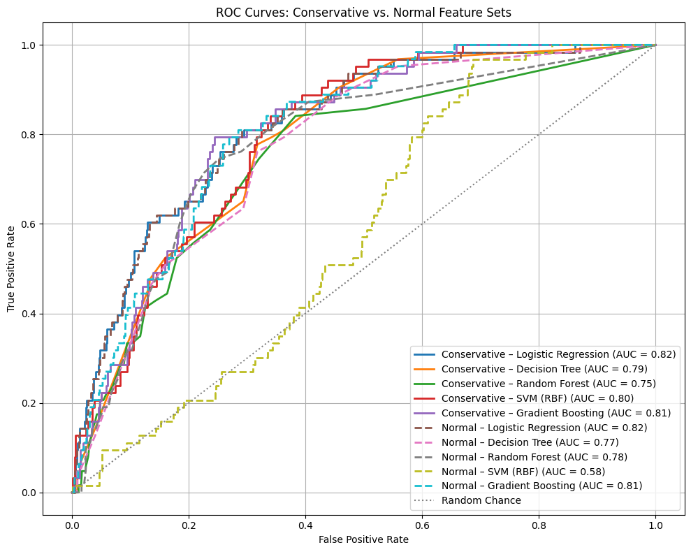

```python
import matplotlib.pyplot as plt
from sklearn.metrics import roc_curve, auc

plt.figure(figsize=(10, 8))

# Conservative feature set (solid lines)
for name, clf in models_conservative.items():
    # Train on the conservative split
    clf.fit(X_train_conservative, y_train_conservative)
    # Predict probabilities for the positive class
    y_prob = clf.predict_proba(X_test_conservative)[:, 1]
    fpr, tpr, _ = roc_curve(y_test_conservative, y_prob)
    roc_auc = auc(fpr, tpr)
    plt.plot(fpr, tpr,
             label=f"Conservative – {name} (AUC = {roc_auc:.2f})",
             linewidth=2)

# Normal feature set (dashed lines)
for name, clf in models.items():
    clf.fit(X_train, y_train)
    y_prob = clf.predict_proba(X_test)[:, 1]
    fpr, tpr, _ = roc_curve(y_test, y_prob)
    roc_auc = auc(fpr, tpr)
    plt.plot(fpr, tpr, linestyle='--',
             label=f"Normal – {name} (AUC = {roc_auc:.2f})",
             linewidth=2)

# Random chance baseline
plt.plot([0, 1], [0, 1],
         linestyle=':', color='gray',
         label='Random Chance')

plt.title("ROC Curves: Conservative vs. Normal Feature Sets")
plt.xlabel("False Positive Rate")
plt.ylabel("True Positive Rate")
plt.legend(loc='lower right')
plt.grid(True)
plt.tight_layout()
plt.show()
```

# Conclusions

Overall, stroke data is very important and represents an issue that acccounts for 11% of deaths every year. The impact of stroke detection is important at a younger age, because it can prevent issues in the future and can allow for patients to take medication and preventative measures beforehand.

Overall, this provides insight into the medical risks of strokes and how well the features given can tell us whether someone may be at risk of a stroke. For those new to the field of machine learning, this notebook can provide more insight into how some of these models work, like logistic regression or gradient boosting. For those who are more familiar, statistical insights and real world applications are clear: Strokes can be at least partially understood by the features we saw, and models are capable of capturing some of the statistical relevance.